# Effect of Loan Variables on Loan Amount

## by Isiaq Adebayo Okeyode

## Investigation Overview

> In this analysis, I'm assuming the role of a Borrower. I want to find out what variable come into play to determine the maximum Loan Amount to be given out to a Borrower? The main focus was StatedMonthlyIncome, DebtToIncomeRatio, Loan Term and ProsperScore.

## Dataset Overview

> The data consists of Loan Original Amount and other variables of approximately 114,000 rows of loan data and 20 columns. A subset of the data was used for the analysis. The features included StatedMonthlyIncome, DebtToIncomeRatio, Loan Term, ProsperScore as well as some additional variables. Some data points were removed due to missing information and inconsistencies.

## Loan Amount Distribution

> The peak values are at around 5,000, 10,000, 15,000, 20,000, 25,000 and 35,000 (in USD). It means that loans are given out in rounded figures and in multiples of 5,000. I observe that majority of loans are given out at 4,000 , 10,000 and 15,000.

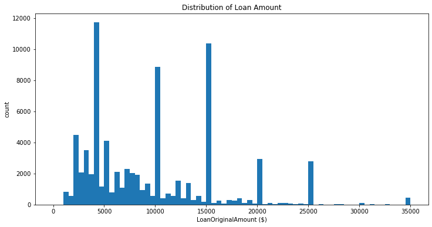

## Distribution of Income Ranges

> People with income ranges of 25,000 to 75,000 (USD) gets the most loan while people with no income gets nothing.

[output not shown]

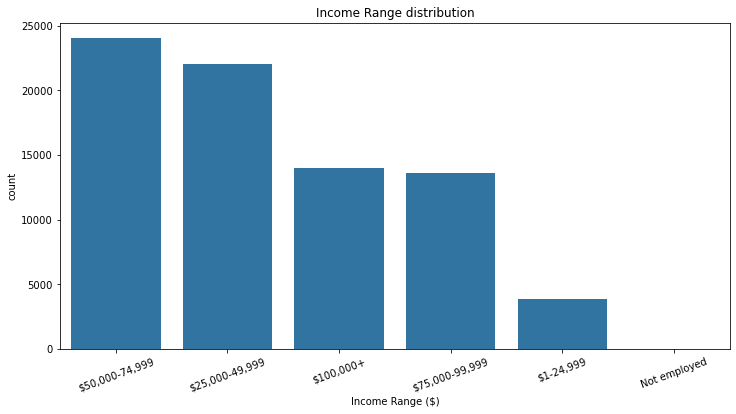

## Distribution of Debt to Income Ratio

> Even though most Lenders prefer a Debt-To-Income-Ratio thats (36%) or leser. But depending on the loan type 50% is a threshold value.

> As seen on the plot above, large spikes in frequency are observed around 0.2 and 0.36. This implies that majority of borrowers have a Debt-To-Income Ratio below the threshhold value.

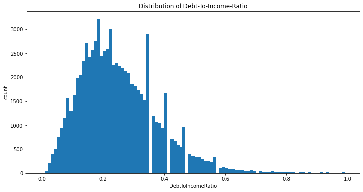

## Distribution of Loan Term

> It is observed that majority of the loan is termed at 36 months (3 years)

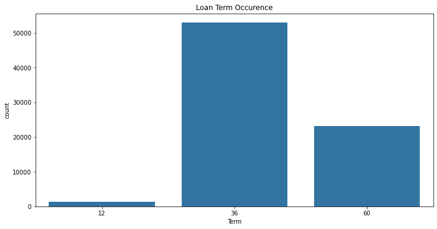

## Distribution of Monthly Loan Payment

> The large number of loaners put the monthly loan payment at approximately 200 dollars. Majority of the monthly loan payment is below 500 dollars.

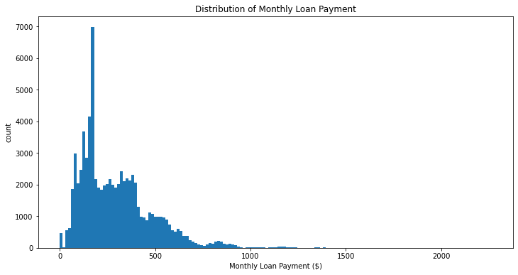

## Distribution of the Year Loan is given most

> Most of the Loans given were generally made in the year 2013 and it dropped in 2014.

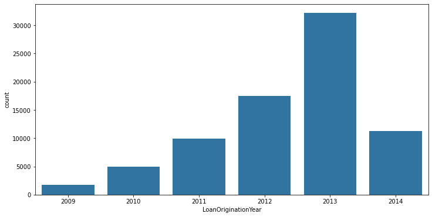

## Distribution of Employment Status

> Most borrower's are gainfully employed or working full time

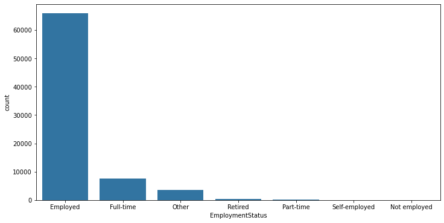

## Are they Home Owners?

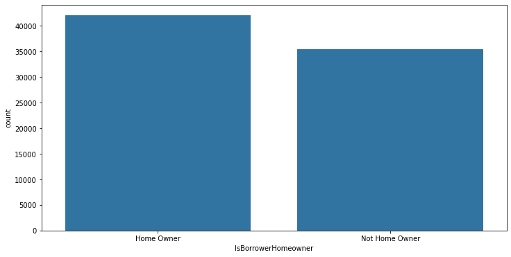

## Distribution of DebtToIncomeRatio and Loan Amount

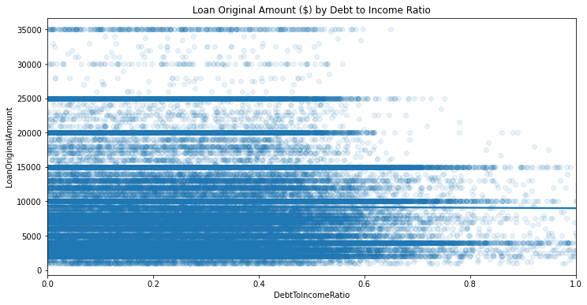

## Distribution of Home Owner and a good risk score on the Loan Amount

> The plot shows that home owners with a good ProsperScore(low risk) is likely to get a Large Loan Amount.

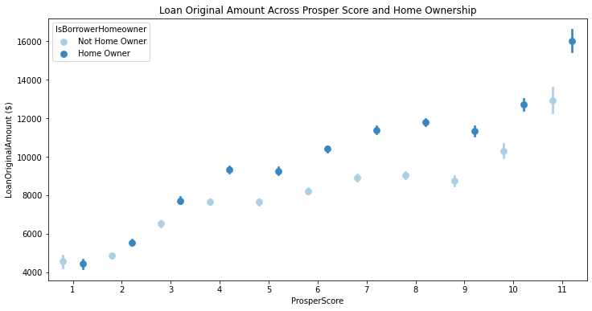

> The plot shows that borrower's with longer Loan Term 36, 60 months receives higher Loan amount. For a maximum Loan Amount of 35,000 the Loan Term is longer,(36 or 60 months)

> I also observed that for a longer Loan Term the scheduled monthly payment is less than that of small term (12months).

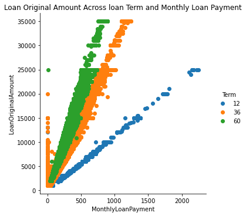

## Loan Term and Prosper score effects on the Loan Amount

> The plot shows that if the Loan Term (in months) is higher (e.g 60 months) and the Prosper Score is high (i.e. less risk), the borrower is more likely to get a large Loan Amount.

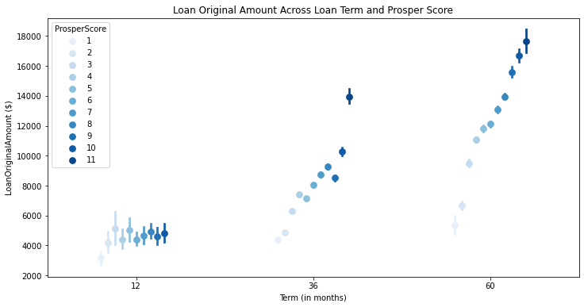